# Analysis of experiment 1

# 6 Effect sizes

This final part of the analysis directly addresses our research questions.

The three effect sizes estimated in this section (one primary, two secondary) capture in three different ways the average increase in the money allocated to SouthEast Asia when its data is shown with an information-rich visualization. Each effect corresponds to a different way of measuring money allocated to SouthEast Asia, which we will call here **DV1**, **DV2**, and **DV3** (for dependent variable).

We will analyze and interpret our results using estimation statistics. See:

- Cumming, G. (2014). [The new statistics: Why and how](https://journals.sagepub.com/doi/pdf/10.1177/0956797613504966). Psychological science, 25(1), 7-29.
- Dragicevic, P. (2016). [Fair statistical communication in HCI](https://hal.inria.fr/hal-01377894/document). In Modern Statistical Methods for HCI (pp. 291-330). Springer, Cham.

All effects in this section are estimated using BCa bootstrap confidence intervals. These provide good interval estimates without distributional assumptions for sample sizes of about 20 or more (we have 64 and 64). See Kirby, K. N., & Gerlanc, D. (2013). [BootES: An R package for bootstrap confidence intervals on effect sizes](https://www.ncbi.nlm.nih.gov/pubmed/23519455). Behavior research methods, 45(4), 905-927.

Since we identify a single primary outcome in this analysis, no adjustment for multiplicitiy is required. We will interpret results for the secondary outcomes as tentative and exploratory, especially if the primary outcome is inconclusive. See:

- Bender, R., & Lange, S. (2001). [Adjusting for multiple testing—when and how?](https://www.ncbi.nlm.nih.gov/pubmed/11297884). Journal of clinical epidemiology, 54(4), 343-349.
- Li, G., et al. (2016). [An introduction to multiplicity issues in clinical trials: the what, why, when and how](https://www.ncbi.nlm.nih.gov/pubmed/28025257). International journal of epidemiology, 46(2), 746-755.

## 6.1 Primary effect

**DV1** = Additional funds allocated to SouthEast Asia / UNHCR compared to the Middle East / IOM (negative if less funds are allocated)

The reported effect of interest is then the difference in mean DV1 between the richFirst and the poorFirst groups. In other words, it is the interaction between the scenario condition (Southeast Asia vs. Middle East, within-subjects) and the visualization order condition (richFirst vs. poorFirst, between-subjects). If information richness has no effect, there should be no interaction. Conversely, if information richness has an effect, the interaction should be non-zero (i.e., positive if information richness prompts people to allocate more money, negative otherwise).

**effect1** = Difference in mean DV1 between the richFirst and the poorFirst groups.

- **Unit**: percent difference. Range: -200, 200.
- **Role**: primary outcome, used to answer the research question (this choice because it’s likely the DV with highest statistical power)

```r
# Set random seed for bootstrapping
set.seed(0)

DV1_rich = data_rich_first$fund_allocation_difference
DV1_poor = data_poor_first$fund_allocation_difference
effect1 = diffMeanCI.bootstrap(DV1_rich, DV1_poor)
cat("Effect 1 = ", formatCI(effect1))
```

```
## Effect 1 =  3.8, 95% CI [-1.7, 9.3]
```

## 6.2 Secondary effects

**DV2** = Percentage of global UNHCR funds allocated to SouthEast Asia (the rest being allocated to other parts of the world)

- It is the response to the first question only. This is the between-subjects analysis, taking into account only the first stimulus.
- **Unit**: percent. Range: 0, 100.

The effect reported here is the difference in mean DV2 between the richFirst and the poorFirst groups.

- **Unit**: percent difference. Range: -100, 100.
- **Role**: secondary outcome (alternative measure that is better able to guarantee that participants are naïve to the purpose of the experiment)

```r
DV2_rich = data_rich_first$fund_allocation_southeast_asia
DV2_poor = data_poor_first$fund_allocation_southeast_asia
effect2 = diffMeanCI.bootstrap(DV2_rich, DV2_poor)
cat("Effect 2 = ", formatCI(effect2))
```

```
## Effect 2 =  2.7, 95% CI [-2.3, 7.9]
```

**DV3** = Percentage of personal money donated to SouthEast Asia / SEARAC (the rest being donated to the Middle East / World Relief)

- It is the response to the third question.
- **Unit**: percent. Range: 0, 100.

The effect reported here is the difference in mean DV3 between the richFirst and the poorFirst groups.

- **Unit**: percent difference. Range: -100, 100.
- **Role**: secondary outcome (alternative to the first reported effect. Will help us determine whether it’s a better way of asking the question).

```r
DV3_rich = data_rich_first$donation_allocation_southeast_asia
DV3_poor = data_poor_first$donation_allocation_southeast_asia
effect3 = diffMeanCI.bootstrap(DV3_rich, DV3_poor)
cat("Effect 3 = ", formatCI(effect3))
```

```
## Effect 3 =  -1.8, 95% CI [-7.1, 3.1]
```

Plot all effect size CIs. We put them in the same plot here only for convenience. The three effect sizes are not on the same scale and can’t be directly compared, so we will probably not combine them in the same plot like here.

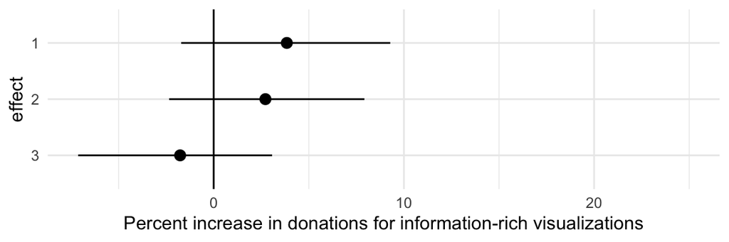

```r
plotAllCIs(lim = c(0, 25), xlabel = "Percent increase in donations for information-rich visualizations")
```

```r
ggsave(filename = "../../paper-figures/exp1-effects.pdf", dpi = 300, width = 6, height = 2)
```

Note that effect 1 is on a different scale from effect 2, and because of the way it is calculated we should expect it to be about twice as large as effect 2. When deciding which measure is the most sensitive (e.g., to inform the design of our next experiment), we should not look at how large each effect is, but at how far its CI is from zero.